# データ分析と線形代数05

UPDATE: 2021-09-25 06:02:19

# はじめに

ここでは[データ分析のための線形代数](https://www.kyoritsu-pub.co.jp/bookdetail/9784320018594)の章末問題をRで回答していきます。

- [データ分析のための線形代数](https://www.kyoritsu-pub.co.jp/bookdetail/9784320018594)

# 表1.1が表すアンケートデータ

```r
D <- matrix(c(1,3,1,1,4,5,26,
              1,2,1,3,1,3,22,
              2,3,1,1,1,5,27,
              1,2,2,1,1,5,34,
              1,2,2,2,3,2,28,
              3,4,1,1,3,5,20,
              4,1,2,3,4,4,18,
              4,4,1,2,4,4,30,
              2,3,2,4,2,4,23,
              1,2,2,1,4,1,32),
            nrow = 10, ncol = 7, byrow = TRUE)
colnames(D) <- paste0("Q", 1:7)
rownames(D) <- paste0("ID", 1:10)

# 1.1のアンケートデータ
D
```

```
##      Q1 Q2 Q3 Q4 Q5 Q6 Q7
## ID1   1  3  1  1  4  5 26
## ID2   1  2  1  3  1  3 22
## ID3   2  3  1  1  1  5 27
## ID4   1  2  2  1  1  5 34
## ID5   1  2  2  2  3  2 28
## ID6   3  4  1  1  3  5 20
## ID7   4  1  2  3  4  4 18
## ID8   4  4  1  2  4  4 30
## ID9   2  3  2  4  2  4 23
## ID10  1  2  2  1  4  1 32
```

# 5章の章末問題

## 5.1 次の1から6の行列の行列式を求めよ。行列式が定義されていない場合は「定義されていない」と答えること。

$$(1)
\begin{bmatrix}
2 & 1 \\
-1 & -2
\end{bmatrix},
(2)
\begin{bmatrix}
3 & 2 & 0 \\
7 & 4 & 0
\end{bmatrix},
(3)
\begin{bmatrix}
1 & 2 \\
-1 & -2 \\
\end{bmatrix}, \\
(4)
\begin{bmatrix}
7 & 0 & 2 \\
5 & -3 & 4 \\
-9 & 1 & 0
\end{bmatrix},
(5)
\begin{bmatrix}
3 & 1 & 7 \\
2 & -3 & 1 \\
-5 & 1 & 9
\end{bmatrix},
(6)
\begin{bmatrix}
-1 & 7 & 2 \\
1 & -5 & -2 \\
-1 & 9 & 2
\end{bmatrix}$$

```r
m1 <- matrix(
  c(2,1,
    -1,-2),
  nrow = 2, ncol = 2, byrow = TRUE)

m2 <- matrix(
  c(3,2,0,
    7,4,0),
  nrow = 2, ncol = 3, byrow = TRUE)

m3 <- matrix(
  c(1,2,
    -1,-2),
  nrow = 2, ncol = 2, byrow = TRUE)

m4 <- matrix(
  c(7,0,2,
    5,-3,4,
    -9,1,0),
  nrow = 3, ncol = 3, byrow = TRUE)

m5 <- matrix(
  c(3,1,7,
    2,-3,1,
    -5,1,9),
  nrow = 3, ncol = 3, byrow = TRUE)

m6 <- matrix(
  c(-1,7,2,
    1,-5,-2,
    -1,9,2),
  nrow = 3, ncol = 3, byrow = TRUE)
```

### 5.1.1

```r
# m1[1,1]*m1[2,2] - m1[1,2]*m1[2,1]
det(m1)
```

```
## [1] -3
```

### 5.1.2

```r
# 定義されない
```

### 5.1.3

```r
# m3[1,1]*m3[2,2] - m3[1,2]*m3[2,1]
det(m3)
```

```
## [1] 0
```

### 5.1.4

```r
det(m4)
```

```
## [1] -72
```

```r
# 第1行の−2倍を第2行に加える
m4[2,] <- m4[2,] + m4[1,]*-2
# 第1行と第3列で余因子展開
# m[i,j]*(-1)^(i+j)*|m|
m4[1,3] * (-1)^(1+3) * det(m4[-1,-3])
```

```
## [1] -72
```

### 5.1.5

```r
det(m5)
```

```
## [1] -198
```

### 5.1.6

```r
det(m6)
```

```
## [1] 0
```

## 5.2 次の1から6の行列階数を求めよ。

$$(1)
\begin{bmatrix}
4 & 1 \\
0 & 0
\end{bmatrix},
(2)
\begin{bmatrix}
1 & -5 \\
-2 & 10 \\
-3 & 15
\end{bmatrix},
(3)
\begin{bmatrix}
0 & 0 & 0 \\
0 & 2 & 1
\end{bmatrix}, \\
(4)
\begin{bmatrix}
-2 & 1 \\
8 & 7 \\
\end{bmatrix},
(5)
\begin{bmatrix}
-5 & 1 & 6 \\
3 & -3 & 4 \\
1 & 1 & 7
\end{bmatrix},
(6)
\begin{bmatrix}
4 & -3 & -7 & 1 & 8 \\
1 & 7 & 6 & -8 & 4
\end{bmatrix}$$

```r
library(matlib)
m1 <- matrix(
  c(4,1,
    0,0),
  nrow = 2, ncol = 2, byrow = TRUE)

m2 <- matrix(
  c(1,-5,
    -2,10,
    -3,15),
  nrow = 3, ncol = 2, byrow = TRUE)

m3 <- matrix(
  c(0,0,0,
    0,2,1),
  nrow = 2, ncol = 3, byrow = TRUE)

m4 <- matrix(
  c(-2,1,
    8,7),
  nrow = 2, ncol = 2, byrow = TRUE)

m5 <- matrix(
  c(-5,1,6,
    3,-3,4,
    1,1,7),
  nrow = 3, ncol = 3, byrow = TRUE)

m6 <- matrix(
  c(4,-3,-7,1,8,
    1,7,6,-8,4),
  nrow = 2, ncol = 5, byrow = TRUE)
```

### 5.2.1

```r
# 第2行はゼロベクトル、第1行は非ゼロベクトル
# 階数は1
R(m1)
```

```
## [1] 1
```

### 5.2.2

```r
# 第1列を−5倍すれば、第2列になる
# 階数は1
R(m2)
```

```
## [1] 1
```

### 5.2.3

```r
# 第1行はゼロベクトル、第2行は非ゼロベクトル
# 階数は1
```

### 5.2.4

```r
# 列、行ベクトルは、一方が他方のスカラ倍ではなく
# 階数は2
R(m4)
```

```
## [1] 2
```

### 5.2.5

```r
# 階数は3
R(m5)
```

```
## [1] 3
```

### 5.2.6

```r
# 2×5行列であり、階数は2以下
# 階数は2
R(m6)
```

```
## [1] 2
```

## 5.3 以下の行列について1から6に答えよ。

$$\begin{bmatrix}
2 & 3 & 4 & 5 \\
0 & 0 & -1 & -4 \\
0 & 1 & 3 & 0 \\
1 & 3 & 0 & 7
\end{bmatrix}$$

```r
m <- matrix(
  c(2,3,4,5,
    0,0,-1,-4,
    0,1,3,0,
    1,3,0,7),
  nrow = 4, ncol = 4, byrow = TRUE)
```

### 5.3.1 第(1,1)要素の余因子

```r
i <- 1
j <- 1
m11 <- m[-1*i, -1*j]
cm11 <- (-1)^(i+j) * det(m11)
cm11
```

```
## [1] 43
```

### 5.3.2 第(1,2)要素の余因子

```r
i <- 1
j <- 2
m12 <- m[-1*i, -1*j]
cm12 <- (-1)^(i+j) * det(m12)
cm12
```

```
## [1] -12
```

### 5.3.3 第(3,2)要素の余因子

```r
i <- 3
j <- 2
m32 <- m[-1*i, -1*j]
cm32 <- (-1)^(i+j) * det(m32)
cm32
```

```
## [1] 25
```

### 5.3.4 第2行を展開して行列式を求めよ

```r
i <- 2
j1 <- 3
j2 <- 4
m[i, j1]*(-1)^(i+j1)*det(m[-1*i, -1*j1]) + m[i, j2]*(-1)^(i+j2)*det(m[-1*i, -1*j2])
```

```
## [1] 61
```

### 5.3.5 第1列を展開して行列式を求めよ

```r
i1 <- 1
i2 <- 4
j <- 1
m[i1, j]*(-1)^(i1+j)*det(m[-1*i1, -1*j]) + m[i2, j]*(-1)^(i2+j)*det(m[-1*i2, -1*j])
```

```
## [1] 61
```

### 5.3.6 第1行から第4行の2倍を引き、第1列を展開して行列式を求めよ

```r
# 第1行から第4行の2倍を引く
m[1,] <- m[1,] - 2*m[4,]
i <- 4
j <- 1
m[i, j]*(-1)^(i+j)*det(m[-1*i, -1*j])
```

```
## [1] 61
```

## 5.4 次の行列の行列式を以下の1から5の手順に従って答えよ。

$$\begin{bmatrix}
2 & 7 & 6 & -8 & 2 \\
0 & 0 & 5 & 0 & 2\\
0 & -4 & -1 & 9 & -3 \\
0 & 0 & 0 & 2 & 7 \\
0 & 0 & 0 & 1 & 0
\end{bmatrix}$$
### 5.4.1 第1列で展開する

```r
# この問題の回答はとばす
# 行列式の答えとして−280が得られる
```

### 5.4.2 展開で得られた行列式の第1行と第2行を入れ換える

### 5.4.3 第1列で展開する

### 5.4.4 第1列で展開する

## 5.5 次の1から4の行列の逆行列を求めよ。正則行列ではない場合には「正則行列ではない」と答え、定義されていない場合には「定義されていない」と答えよ。

$$(1)
\begin{bmatrix}
1 & 4 \\
-1 & 5
\end{bmatrix},
(2)
\begin{bmatrix}
-1 & 2 \\
2 & -4
\end{bmatrix},
(3)
\begin{bmatrix}
3 & 2 & 1 \\
-5 & 1 & 2
\end{bmatrix},
(4)
\begin{bmatrix}
1 & 0 & -1 \\
2 & -2 & 0 \\
0 & 3 & 1
\end{bmatrix}$$

```r
m1 <- matrix(
  c(1,4,
    -1,5),
  nrow = 2, ncol = 2, byrow = TRUE)

m2 <- matrix(
  c(-1,2,
    2,-4),
  nrow = 2, ncol = 2, byrow = TRUE)

m3 <- matrix(
  c(3,2,1,
    -5,1,2),
  nrow = 2, ncol = 3, byrow = TRUE)

m4 <- matrix(
  c(1,0,-1,
    2,-2,0,
    0,3,1),
  nrow = 3, ncol = 3, byrow = TRUE)
```

### 5.5.1

```r
det(m1)
```

```
## [1] 9
```

```r
solve(m1)
```

```
##           [,1]       [,2]
## [1,] 0.5555556 -0.4444444
## [2,] 0.1111111  0.1111111
```

### 5.5.2

```r
# 行列式は0であり、正則行列ではない
det(m2)
```

```
## [1] 0
```

### 5.5.3

```r
# 定義されない
```

### 5.5.4

```r
det(m4)
```

```
## [1] -8
```

```r
solve(m4)
```

```
##       [,1]   [,2] [,3]
## [1,]  0.25  0.375 0.25
## [2,]  0.25 -0.125 0.25
## [3,] -0.75  0.375 0.25
```

## 5.6 次の1と2について、行列の列からなるベクトルが直交しているかどうかを調べ、直行している場合には、列からベクトルを基準化し、基準化したベクトルを列に持つ行列式が5.128を満たすことを確かめよ。

$$(1)
\begin{bmatrix}
6 & 4 \\
-8 & 3
\end{bmatrix},
(2)
\begin{bmatrix}
2 & 1 & -2 \\
1 & -2 & 4 \\
0 & 2 & 5
\end{bmatrix}$$

```r
m1 <- matrix(
  c(6,4,
    -8,3),
  nrow = 2, ncol = 2, byrow = TRUE)

m2 <- matrix(
  c(2,1,-2,
    1,-2,4,
    0,2,5),
  nrow = 3, ncol = 3, byrow = TRUE)
```

```r
m11 <- m1[,1]
m12 <- m1[,2]
# 内積は0で直交
t(m11) %*% m12
```

```
##      [,1]
## [1,]    0
```

```r
# 各ベクトルの長さ
norm_m11 <- sqrt(sum(m11^2))
norm_m11
```

```
## [1] 10
```

```r
norm_m12 <- sqrt(sum(m12^2))
norm_m12
```

```
## [1] 5
```

```r
# 基準化したベクトルを列に持つ
m1_scale <- cbind((m1[,1] / norm_m11), (m1[,2] / norm_m12))
m1_scale
```

```
##      [,1] [,2]
## [1,]  0.6  0.8
## [2,] -0.8  0.6
```

```r
# 直交行列の転置行列と直交行列の積は単位行列
t(m1_scale) %*% m1_scale
```

```
##      [,1] [,2]
## [1,]    1    0
## [2,]    0    1
```

```r
m21 <- m2[,1]
m22 <- m2[,2]
m23 <- m2[,3]
# 内積は0で直交
t(m21) %*% m22
```

```
##      [,1]
## [1,]    0
```

```r
t(m22) %*% m23
```

```
##      [,1]
## [1,]    0
```

```r
t(m23) %*% m21
```

```
##      [,1]
## [1,]    0
```

```r
# 各ベクトルの長さ
norm_m21 <- sqrt(sum(m21^2))
norm_m21
```

```
## [1] 2.236068
```

```r
norm_m22 <- sqrt(sum(m22^2))
norm_m22
```

```
## [1] 3
```

```r
norm_m23 <- sqrt(sum(m23^2))
norm_m23
```

```
## [1] 6.708204
```

```r
# 基準化したベクトルを列に持つ
m2_scale <- cbind((m2[,1] / norm_m21), (m2[,2] / norm_m22), (m2[,3] / norm_m23))
m2_scale
```

```
##           [,1]       [,2]       [,3]
## [1,] 0.8944272  0.3333333 -0.2981424
## [2,] 0.4472136 -0.6666667  0.5962848
## [3,] 0.0000000  0.6666667  0.7453560
```

```r
# 直交行列の転置行列と直交行列の積は単位行列
t(m2_scale) %*% m2_scale
```

```
##      [,1] [,2] [,3]
## [1,]    1    0    0
## [2,]    0    1    0
## [3,]    0    0    1
```

## 5.7 表1.1の回答者1から5の設問5と6に対する回答を用いて、1から8に答えよ。

```r
D56 <- D[1:5, 5:6]
D56
```

```
##     Q5 Q6
## ID1  4  5
## ID2  1  3
## ID3  1  5
## ID4  1  5
## ID5  3  2
```

### 5.7.1 偏差行列を求めよ。

```r
D5_m <- mean(D56[,1])
D6_m <- mean(D56[,2])

D_hensa <- cbind(D56[,1] - D5_m, D56[,2] - D6_m)
D_hensa
```

```
##     [,1] [,2]
## ID1    2    1
## ID2   -1   -1
## ID3   -1    1
## ID4   -1    1
## ID5    1   -2
```

### 5.7.2 設問5と6の横座標と縦座標にとり、偏差行列の散布図を描け。

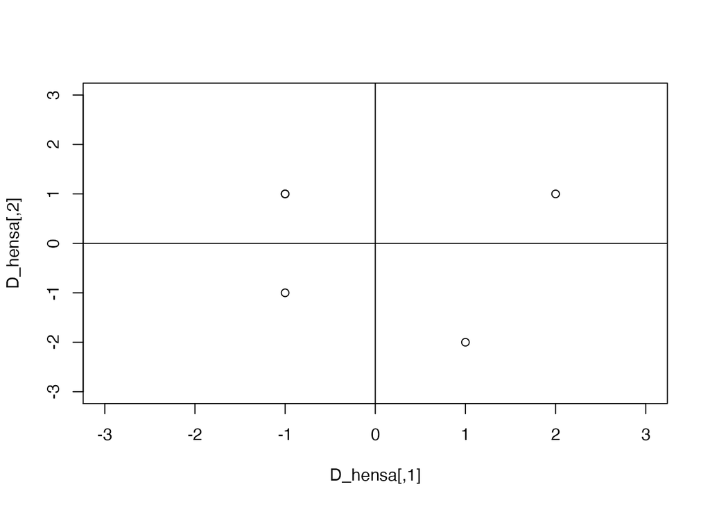

```r
plot(D_hensa, xlim = c(-3, 3), ylim = c(-3, 3))
abline(h = 0, v = 0)
```

### 5.7.3 設問5の座標の2乗和と設問6の座標の2乗和を求めよ。

```r
sum(D_hensa[,1]^2)
```

```
## [1] 8
```

```r
sum(D_hensa[,2]^2)
```

```
## [1] 8
```

### 5.7.4 設問5と6各々の分散を求めよ。

```r
sum(D_hensa[,1]^2)/nrow(D_hensa)
```

```
## [1] 1.6
```

```r
sum(D_hensa[,2]^2)/nrow(D_hensa)
```

```
## [1] 1.6
```

### 5.7.5 分散の5倍が座標の2乗和になることを、設問5と設問6の各々について確かめよ。

```r
nrow(D_hensa) * sum(D_hensa[,1]^2)/nrow(D_hensa) == sum(D_hensa[,1]^2)
```

```
## [1] TRUE
```

```r
nrow(D_hensa) * sum(D_hensa[,2]^2)/nrow(D_hensa) == sum(D_hensa[,2]^2)
```

```
## [1] TRUE
```

### 5.7.6 散布図の座標軸を反時計回りに30度回転したときに得られる次元での5人の回答者の座標を求めよ。

```r
R <- matrix(c(sqrt(3)/2, 1/2,
              -1/2, sqrt(3)/2),
            nrow = 2, ncol = 2, byrow = TRUE)
R1 <- R %*% t(D_hensa)
R1
```

```
##             ID1        ID2        ID3        ID4        ID5
## [1,]  2.2320508 -1.3660254 -0.3660254 -0.3660254 -0.1339746
## [2,] -0.1339746 -0.3660254  1.3660254  1.3660254 -2.2320508
```

```r
R2 <- D_hensa %*% t(R)
R2
```

```
##           [,1]       [,2]
## ID1  2.2320508 -0.1339746
## ID2 -1.3660254 -0.3660254
## ID3 -0.3660254  1.3660254
## ID4 -0.3660254  1.3660254
## ID5 -0.1339746 -2.2320508
```

### 5.7.7 上の6の次元の座標の2乗和を、2つの次元の各々について求めよ。

```r
sum(R2[,1]^2)
```

```
## [1] 7.133975
```

```r
sum(R2[,2]^2)
```

```
## [1] 8.866025
```

### 5.7.8 上の7の2つの2乗和が、3で求めた2つの2乗和の和に等しいことを確かめよ。

```r
all.equal(sum(D_hensa[, 1] ^ 2) + sum(D_hensa[, 2] ^ 2),　sum(R2[, 1] ^ 2) + sum(R2[, 2] ^ 2))
```

```
## [1] TRUE
```